# Data visualization with ggplot2

# Introduction to data visualisation with ggplot2

## Chapter 1 - Introduction

### Section 1 - Introduction

#### Exploratory vs. explanatory analysis

- Exploratory - confirm and analyse
- Explanatory - inform and persuade

### Loading dataset

```r
library(MASS)
library(ggplot2)
mammals
```

|  | body | brain |
| --- | --- | --- |
| Arctic fox | 3.385 | 44.50 |
| Owl monkey | 0.480 | 15.50 |
| Mountain beaver | 1.350 | 8.10 |
| Cow | 465.000 | 423.00 |
| Grey wolf | 36.330 | 119.50 |
| Goat | 27.660 | 115.00 |
| Roe deer | 14.830 | 98.20 |
| Guinea pig | 1.040 | 5.50 |
| Verbet | 4.190 | 58.00 |
| Chinchilla | 0.425 | 6.40 |

[output cut: 52 more lines]

#### A Scatter plot

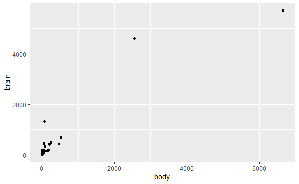

```r
ggplot(mammals, aes(x = body, y = brain)) +
  geom_point()
```

#### Explore with a linear model

- Poor choice, since a few extreme values have a large influence

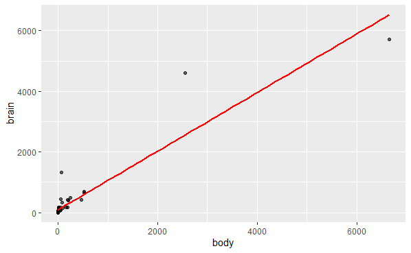

```r
ggplot(mammals, aes(x = body, y = brain)) +
  geom_point(alpha = 0.6) +
  stat_smooth(
    method = "lm",
    color = "red",
    se = FALSE
  )
```

#### Explore - fine tuning

- Log transformation allows for a better fit

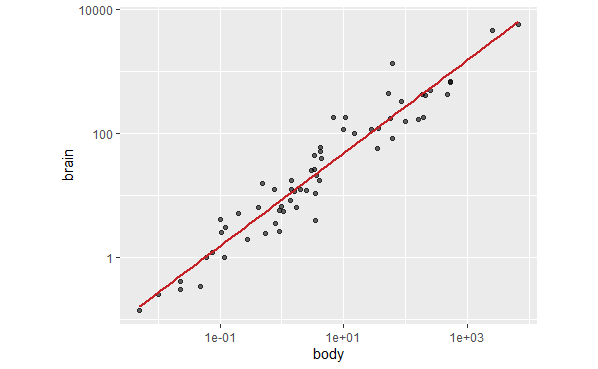

```r
ggplot(mammals, aes(x = body, y = brain)) +
  geom_point(alpha = 0.6) +
  coord_fixed() +
  scale_x_log10() +
  scale_y_log10() +
  stat_smooth(
    method = "lm",
    color = "#C42126",
    se = FALSE,
    size = 1
  )
```

#### Anscombe’s plots

- Example of how different datasets can lead to the same linear plots despite different relationships

#### Using factors in scatter plots

- Wrap `factor()` around the variable and the axis will adjust to show only the relevant points

### Section 2 - The grammar of graphics

- Build on an underlying grammar

#### The grammar of graphics

- Plotting framework
- Leland Wilkinson 1999
- 2 principles
  - Graphics = distinct layers of grammatical elements
  - Meaningful plots through aesthetic mappings

- Data - the data-set being plotted
- Aesthetics - the scales onto which we *map* our data
- Geometrics - the visual elements used for our plot
- Themes - all non-data ink
- Statistics - representations of our data to aid understanding
- Coordinates - the space on which the data will be plotted
- Facets - plotting small multiples

#### Understanding variables

- can use color inside aes
- can use size inside aes
- can use shape inside aes - data must be categorical

### Section 3 - ggplot2 layers

#### ggplot2 package

- The grammar of graphics is implemented in R
- Two key concepts:
  1. Layer grammatical elements
  2. Aesthetic mappings

#### Data

- Bottom layer
- Using - iris dataset

```r
iris
```

| Sepal.Length | Sepal.Width | Petal.Length | Petal.Width | Species |
| --- | --- | --- | --- | --- |
| 5.1 | 3.5 | 1.4 | 0.2 | setosa |
| 4.9 | 3.0 | 1.4 | 0.2 | setosa |
| 4.7 | 3.2 | 1.3 | 0.2 | setosa |
| 4.6 | 3.1 | 1.5 | 0.2 | setosa |
| 5.0 | 3.6 | 1.4 | 0.2 | setosa |
| 5.4 | 3.9 | 1.7 | 0.4 | setosa |
| 4.6 | 3.4 | 1.4 | 0.3 | setosa |
| 5.0 | 3.4 | 1.5 | 0.2 | setosa |
| 4.4 | 2.9 | 1.4 | 0.2 | setosa |
| 4.9 | 3.1 | 1.5 | 0.1 | setosa |

[output cut: 140 more lines]

#### Aesthetics

- Next layer
- Tells us scales we should map our data to
- Establish aesthetic mappings
- `sepal.length = x`
- `sepal.width = y`

#### Geometrics

- Allows us to choose how the plot will look

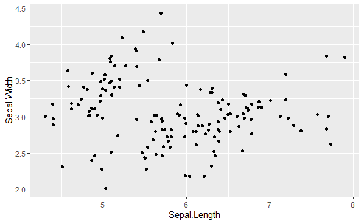

```r
g <- ggplot(iris, aes(x = Sepal.Length, y = Sepal.Width)) +
  geom_jitter()
g
```

#### Themes

- Controls all non-data ink on plot

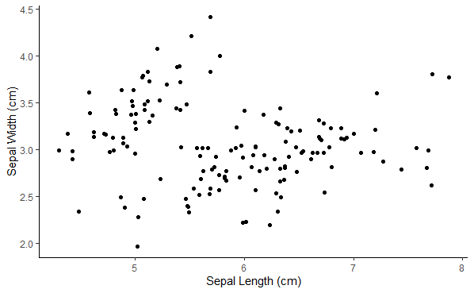

```r
g <- g +
  labs(x = "Sepal Length (cm)", y = "Sepal Width (cm)") +
  theme_classic()
g
```

#### Adding geometries

- geom_point() - adds points (as in a scatter plot)
- geom_smooth() - adds a smooth trend curve
- These can be labelled

#### Changing one geom or every geom

- Mapping an aesthetic to data variable inside the call to `ggplot()` will change *all* the geoms
- It is also possible to make changes to *individual* geoms by passing arguments to the `geom_*()` functions
- E.g. geom_point(alpha = 0.4)

#### Saving plots as variables

- Plots can be saved as variables, which can be added to later on using the `+` operator. This is useful if you want to make multiple related plots from a common base

## Chapter 2 - Aesthetics

### Section 1 - Visible aesthetics

#### Mapping onto the X and Y axes

```r
ggplot(iris, aes(x = Sepal.Length, y = Sepal.Width, color = Species)) +
  geom_point()
```

- Mapping sepal length onto X aesthetic, sepal width onto y aesthetic
- species can be mapped onto the color aesthetic
- Map aesthetics in the `aes()` function
- Could call in the `geom_*()` function
  - Typically only necessarily if all layers should *not* inherit the same aesthetics
  - Or if mixing different data sources
- Try to keep data and ggplot aesthetics in the same function definition
- Typical visible aesthetics
  - x
  - y
  - fill - fill color
  - color - color of points, outlines of other geoms
  - size - area of radius of points, thinkness of lines
  - alpha - transparency
  - linetype - line dash pattern
  - labels - text on a plot or axes, categorical data only
  - shape - point shape, categorical data only
- Function as both aes and attributes

#### All about aesthetics: color, shape and size

- Aesthetics you can consider within aes:
  - `x`
  - `y`
  - `color`
  - `fill`
  - `size`
  - `alpha`
  - `labels`
  - `shape` - 1 (empty circles)
- Common convention - you don’t name the `x` and `y` arguments to `aes()` as they always come first, but you do name the other arguments

#### All about aesthetics: color vs. fill

- `color` typically changes the *outline* of a geom and the `fill` aesthetic changes the inside
- `geom_point()` is an exception - you use `color` (not `fill`) for the point color, but some shapes have special behaviour
- The default `geom_point()` uses `shape = 19`, a solid circle
- An alternative is `shape = 21` - a circle that allows you to use *both* `fill` for the inside and `color` for the outside

### Section 2 - Using attributes

- Attributes - how something looks
- All visible aesthetics also exist as attributes
- Attributes always called in the geom layer

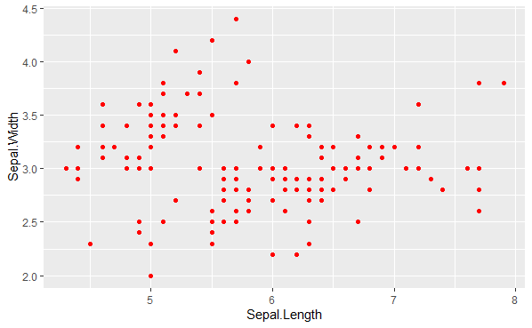

```r
ggplot(iris, aes(x = Sepal.Length, y = Sepal.Width)) +
  geom_point(color = 'red')
```

- e.g. Color - attribute set using color argument
- size
- shape
- You can use all the aesthetics as attributes (but as attributes, they are not mapped to variables)
- E.g. Setting labels to row names `labels = rownames(series)`

### Section 3 - Modifying aesthetics

#### Positions

- Adjustment for overlapping
  - `identity` - the most straightforward position, default - value in df is where it is positioned in the plot
  - `dodge` - for bars this unstacks bars and sets side-by-side
  - `stack`
  - `fill`
  - `jitter`
  - `jitterdodge`
  - `nudge`

```r
ggplot(iris, aes(x = Sepal.Length,
                 y = Sepal.Width,
                 color = Species)) +
  geom_point(position = "identity")
```

- Too much overplotting to distinguish the points
- Need to add some random noise on the x and y axes to see regions of high density - jittering

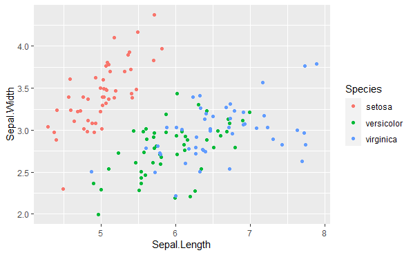

```r
ggplot(iris, aes(x = Sepal.Length,
                 y = Sepal.Width,
                 color = Species)) +
  geom_point(position = "jitter")
```

- Each position type can be used as an argument or accessed as a function

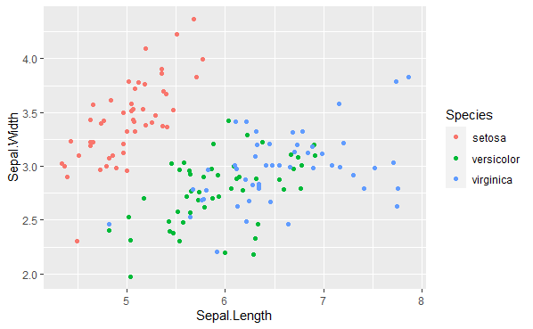

```r
posn_j <- position_jitter(0.1)

ggplot(iris, aes(x = Sepal.Length,
                 y = Sepal.Width,
                 color = Species)) +
  geom_point(position = posn_j)
```

- Benefits of using as function
  - Can set arguments for the position - such as how much random noise should be added
  - Allows for consistency across plots and layers
- Applies for all other position attributes

#### Scale functions

- Each of the aesthetics is a scale that we map the data onto
- We can access all scales with the `scale_` functions
- The second part specifies which scale we want to modify
- All aesthetics have an associated scale function
  - `scale_x_*()`
  - `scale_y_*()`
  - `scale_color_*()` (also `scale_colour_*()`)
  - `scale_fill_*()`
  - `scale_shape_*()`
  - `scale_linetype_*()`
  - `scale_size_*()`
- Scale functions - must be appropriate for the type of data we are using
  - **`scale_x_continuous()`**
  - `scale_y_*()`
  - **`scale_color_discrete()`**
    - Alternatively, `scale_colour_*()`
  - `scale_fill_*()`
  - `scale_shape_*()`
  - `scale_linetype_*()`
  - `scale_linetype_*()`
  - `scale_size_*()`

#### `scale_*_*()

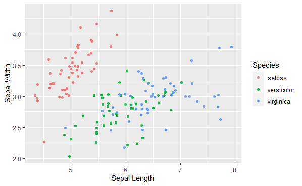

```r
ggplot(iris, aes(x = Sepal.Length,
                 y = Sepal.Width,
                 color = Species)) +
  geom_point(position = 'jitter') +
  scale_x_continuous("Sepal Length") +
  scale_color_discrete("Species")
```

#### The limits argument

- Describe the scales range

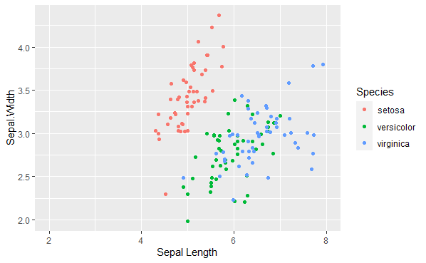

```r
ggplot(iris, aes(x = Sepal.Length,
                 y = Sepal.Width,
                 color = Species)) +
  geom_point(position = 'jitter') +
  scale_x_continuous("Sepal Length",
                     limits = c(2,8)) +
  scale_color_discrete("Species")
```

#### The breaks argument

- Control tickmarks positions

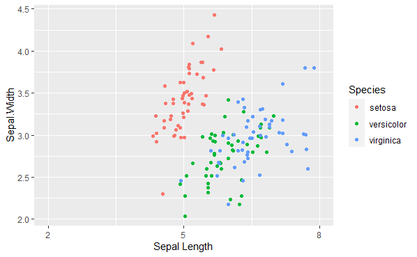

```r
ggplot(iris, aes(x = Sepal.Length,
                 y = Sepal.Width,
                 color = Species)) +
  geom_point(position = 'jitter') +
  scale_x_continuous("Sepal Length",
                     limits = c(2,8),
                     breaks = seq(2, 8, 3)) +
  scale_color_discrete("Species")
```

#### The expand argument

- Numerical factor of length 2, giving a multiplicative, additive constant, used to expand the range of the scales so that there is a small gap between the data and the axes

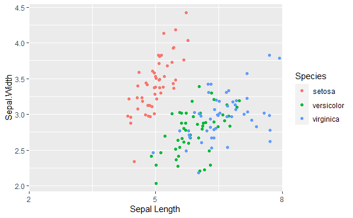

```r
ggplot(iris, aes(x = Sepal.Length,
                 y = Sepal.Width,
                 color = Species)) +
  geom_point(position = 'jitter') +
  scale_x_continuous("Sepal Length",
                     limits = c(2,8),
                     breaks = seq(2, 8, 3),
                     expand = c(0,0)) +
  scale_color_discrete("Species")
```

#### The labels argument

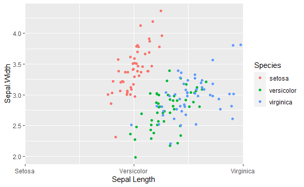

```r
ggplot(iris, aes(x = Sepal.Length,
                 y = Sepal.Width,
                 color = Species)) +
  geom_point(position = 'jitter') +
  scale_x_continuous("Sepal Length",
                     limits = c(2,8),
                     breaks = seq(2, 8, 3),
                     expand = c(0,0),
                     labels = c("Setosa", "Versicolor", "Virginica")) +
  scale_color_discrete("Species")
```

#### labs()

- To quickly change the axis labels

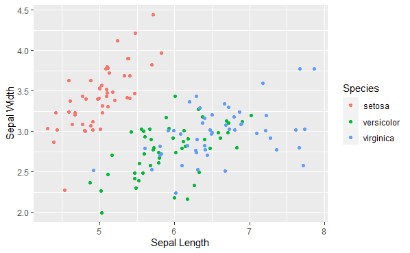

```r
ggplot(iris, aes(x = Sepal.Length,
                 y = Sepal.Width,
                 color = Species)) +
  geom_point(position = 'jitter') +
  labs(x = "Sepal Length", y = "Sepal Width", color = "Species")
```

#### Updating aesthetic labels

- `scale_color_manual()`
  - Defines the properties of the color scale (i.e. axis)
  - The first argument sets the legend title
  - `values` is a named vector of colors to use

#### Setting a dummy aesthetic

- You can make univariate plots in `ggplot2` but you will need to add a fake y axis by mapping `y` to zero
- When setting y-axis limits, you can specify the limits as separate arguments, or as a single numeric vector. That is, `ylim(lo, hi)` or `ylim(c(lo, hi))`

### Section 4: Aesthetics best practices

#### Which aesthetics?

- Some clear guidelines to follow
- Jacques Bertin - The Semiology of Graphics, 1967
- William Cleveland
  - The Elements of Graphing Data, 1985
  - Visualizing Data, 1993

#### Form follows function

- Function depends on audience
- Primary:
  - Accurate and efficient representations
- Secondary:
  - Visually appealing, beautiful plots
- Guiding principles:
  - Never - misrepresent or obscure data, or confuse viewers with complexity
  - Always - consider the audience and purpose of every plot

#### Extracting information from data

- Encoding numbers and text into visual medium

#### The best choices for aesthetics

- Efficient - provides a faster overview than numeric summaries
- Accurate - minimises information loss

#### Choices for mapping continuous variables

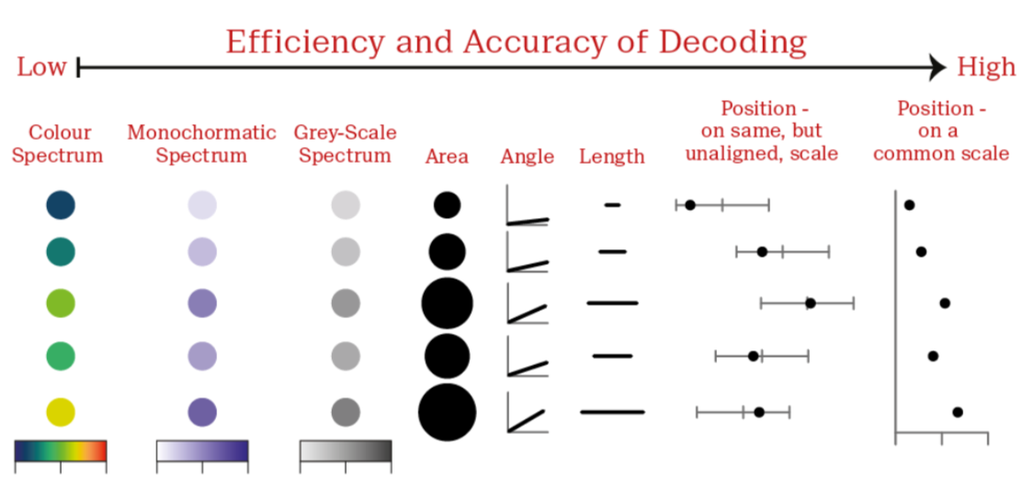

- Color good for categorical variables - Watch out for overplotting - Could adjust position